# Shapley values

Araceli Seiffe y Marina Lagos

Diciembre 2022

# Algoritmo

Antes de avanzar con el ejemplo, vamos a ver cómo se estiman los valores de Shapley. Si bien en la primera parte vimos cómo calcularlos de manera exacta, cuando la cantidad de variables aumenta el número de posibles coaliciones que deben evaluarse crece exponencialmente. Strumbelj & Kononenko (2014) proponen una aproximación por el método de Monte Carlo:

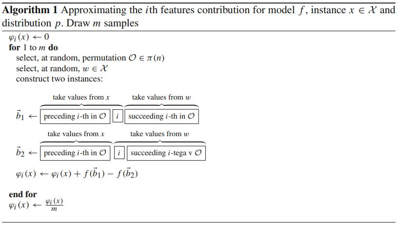

# Librerías en R para estimar Shapley values

- shapr (Actualmente en proceso de reestructuración profunda)
- shapper
- fastshap

# Ejemplo

Se va a trabajar con un modelo (random forest) de predicción de salario de jugadores de la NBA en base a sus estadísticas.

### Librerías

```r
library(readxl)
library(dplyr)
library(tidymodels)
library(tidyverse)
library(fastDummies)
library(caTools)
library(ranger)
library(fastshap)
library(ggplot2)
```

### Datos

Los datos provienen de la página [Basketball Reference](https://www.basketball-reference.com/about/glossary.html) y fueron previamente procesados por el equipo docente de la materia “Enfoque Estadístico del aprendizaje” (Maestría en Explotación de Datos y Descubrimiento del Conocimiento - UBA).

```r
path_datos <- "C:/Users/marin/Maestria/2022_2C/02_EEA/02_TP_final/00_Datos"
diccionario <- read.csv(paste0(path_datos, '/diccionario_terminos.csv'))
diccionario
```

| variable | descripcion |
| --- | --- |
| Player | nombre |
| Pos | Posición |
| Age | Edad |
| G | Partidos |
| GS | Partidos que comenzó como titular |
| MP | Minutos jugados |
| PTS | Points |
| FG | Field Goals |
| FGA | Field Goal Attempts |
| FG% | Field Goal Percentage |

[output cut: 38 more lines]

```r
estad <- read.csv(paste0(path_datos, "/estadisticas_2022.csv"))
salario <- read.csv(paste0(path_datos, "/salarios_nba_2023.csv"))
df = merge(x=estad,y=salario,by="jugador",all=TRUE)
df<-na.omit(df)
glimpse(df)
```

```
## Rows: 409
## Columns: 31
## $ jugador <chr> "Aaron Gordon", "Aaron Holiday", "Aaron Nesmith", "Aaron Wiggi…
## $ Pos     <chr> "PF", "PG", "SF", "SG", "C", "SG", "PF", "SG", "C", "C", "SG",…
## $ Age     <int> 26, 25, 22, 23, 35, 30, 20, 27, 28, 19, 24, 28, 26, 22, 28, 20…
## $ Tm      <chr> "DEN", "TOT", "BOS", "OKC", "BOS", "NYK", "OKC", "CHI", "SAC",…
## $ G       <int> 75, 63, 52, 50, 69, 81, 61, 41, 39, 72, 69, 73, 73, 57, 40, 72…
## $ GS      <int> 75, 15, 3, 35, 69, 44, 12, 18, 10, 13, 30, 36, 73, 30, 40, 72,…
## $ MP      <int> 2376, 1021, 574, 1209, 2005, 2318, 1233, 1147, 620, 1489, 1567…
## $ FG      <int> 434, 151, 72, 156, 266, 285, 186, 102, 94, 249, 211, 247, 475,…
## $ FGA     <int> 834, 338, 182, 337, 569, 728, 456, 256, 176, 525, 466, 433, 10…
## $ FG.     <dbl> 0.520, 0.447, 0.396, 0.463, 0.467, 0.391, 0.408, 0.398, 0.534,…
## $ X3P     <int> 87, 39, 31, 42, 89, 157, 57, 42, 6, 29, 96, 0, 157, 179, 13, 2…
## $ X3PA    <int> 260, 103, 115, 138, 265, 389, 197, 126, 21, 117, 254, 3, 399, …
## $ X3P.    <dbl> 0.335, 0.379, 0.270, 0.304, 0.336, 0.404, 0.289, 0.333, 0.286,…
```

[output cut: 18 more lines]

Partición Train/Test:

```r
set.seed(123)
split = sample.split(df$salario, SplitRatio = 0.75)
training_set = subset(df, split == TRUE)
test_set = subset(df, split == FALSE)
```

### RandomForest

```r
set.seed(42)
rfo <- ranger(salario ~ .,
              data =  select(training_set, -"jugador"),
              num.trees = 100) #1000
```

RMSE:

```r
y_pred = predict(rfo, select(test_set, -"jugador"))$predictions
print(sqrt(mean((y_pred-test_set$salario)^2)))
```

```
## [1] 7116397
```

### SHAP

Documentación: https://bgreenwell.github.io/fastshap/articles/fastshap.html

```r
pfun <- function(object, newdata) {
  predict(object, data = newdata)$predictions
}

X <- subset(select(training_set, -"jugador"), select = -salario)
set.seed(42)
shap <- explain(rfo, X = X, pred_wrapper = pfun, nsim = 100)
shap
```

| Pos | Age | Tm | G | GS | MP | FG | FGA | FG. | X3P | X3PA | X3P. | X2P | X2PA | X2P. | eFG. | FT | FTA | FT. | ORB | DRB | TRB | AST | STL | BLK | TOV | PF | PTS | equipo |
| --- | --- | --- | --- | --- | --- | --- | --- | --- | --- | --- | --- | --- | --- | --- | --- | --- | --- | --- | --- | --- | --- | --- | --- | --- | --- | --- | --- | --- |
| 23599.7992 | 844857.05 | -1643.8580 | -978505.9345 | 1211514.260 | -836559.556 | 1423269.2835 | 770089.65 | 85162.51872 | 173376.449 | 611772.023 | -53202.6707 | 855508.744 | 1141598.180 | 20625.2000 | 220397.695 | 679532.45 | 552306.636 | -87329.685 | -343612.45913 | -85094.7851 | -71850.9298 | -99620.8468 | -217598.0209 | -45475.4707 | 277111.21926 | -274324.7821 | 1910654.69 | 8682.8035 |
| -44141.7814 | -968604.27 | 187795.3696 | 5964.5655 | -884506.081 | 291008.388 | -863863.2794 | -788377.57 | -24645.13160 | -332052.320 | -543825.515 | -7039.2067 | -256267.770 | -326000.582 | -1405.5231 | -76940.300 | -391731.62 | -264072.432 | 112403.931 | 114907.09686 | -139379.6877 | -16946.7742 | -220275.9008 | 215172.3232 | -55094.5610 | -166088.93807 | 2015.5882 | -780435.33 | -39179.6452 |
| -60465.5680 | 1063679.25 | -127055.1504 | -828125.7709 | 1006571.112 | -480564.880 | -53829.5823 | 756642.19 | -181607.27108 | 243858.874 | 486802.303 | -75849.0172 | -229159.733 | -186238.968 | -269383.8338 | -94201.521 | 265247.36 | 523537.641 | -7067.840 | -89075.84974 | 89221.8243 | -62700.0181 | -65525.6877 | -112657.0003 | 15988.4640 | -52287.71595 | -693393.3993 | 1562831.97 | -98899.8499 |
| 40944.0351 | -995091.09 | -88059.3340 | -390799.5674 | 24625.505 | 198626.055 | -374708.1707 | -470999.42 | -91568.80433 | -310124.684 | -19650.473 | -14741.1015 | -228472.087 | -244947.740 | -7795.2847 | -116822.125 | -367767.85 | -206838.180 | -76704.710 | -76306.90372 | 72247.6872 | -5101.8921 | -209691.5222 | -194522.3082 | 77418.8249 | 36178.56892 | -35817.8294 | -783829.31 | -36207.8264 |
| 59265.2401 | 300281.67 | -41568.5523 | 452764.7341 | -807279.830 | 174394.223 | -1261913.3965 | -659327.47 | -74.97024 | -298077.276 | -493750.993 | 87788.2390 | -314805.086 | -251491.046 | -86594.6244 | 54692.673 | -364700.46 | -450630.764 | -289801.024 | -78093.23859 | -105137.6190 | -245087.7268 | -268813.5126 | 427412.9030 | 8577.5382 | -55921.98608 | 5718.4143 | -998276.00 | 38096.9555 |
| -1249.1039 | -1239622.60 | -33598.5422 | -681712.1314 | -74121.208 | 24935.697 | -321513.9141 | -455858.99 | -20968.39111 | -188373.840 | -96141.878 | 16817.0824 | -128675.732 | -119124.939 | 28783.3154 | -104538.131 | 148979.20 | 202686.543 | -149436.411 | -125449.92390 | 103820.5167 | -41908.0162 | -34380.7692 | -70731.6514 | -2826.4897 | 189781.31848 | -629518.5842 | -824363.59 | -83263.7579 |
| 6360.1525 | 408795.18 | -84609.7804 | -512215.0037 | 561605.064 | 146592.309 | -74311.8896 | -641547.30 | -39469.93634 | -159872.537 | -417852.518 | 93837.5686 | -131957.283 | -427202.804 | -139143.4263 | -29400.815 | -455164.70 | -168357.692 | 71656.203 | -186530.81566 | 101022.5128 | 191515.7964 | -265720.9955 | -52808.1089 | -88982.5970 | 76513.15208 | -337894.7981 | -916819.28 | 45857.7673 |
| -66084.5273 | 1514314.93 | 66188.7020 | -508924.7604 | 1688670.598 | -435116.080 | 2531885.2021 | 1967989.27 | 126201.18638 | 170492.153 | 616842.441 | 47767.4429 | 1191140.697 | 1738827.760 | 346404.2071 | 371929.537 | 191971.38 | 1368848.995 | 255692.796 | -61134.80609 | 365917.3652 | 223997.3471 | 86954.3232 | 206274.5371 | 540743.6386 | 366484.45498 | -444040.0158 | 3174123.19 | 68635.9026 |
| 2443.7167 | -1108899.29 | -30042.4343 | -287797.4192 | 841246.431 | -101154.997 | 1387501.0993 | 1265473.78 | 134329.02504 | 680474.663 | 1118088.425 | -34416.4804 | 110202.840 | -39195.419 | 50233.4982 | 206006.511 | -115228.67 | -206672.867 | -11649.554 | 110386.68733 | 438151.8845 | 1192.7567 | 219375.7497 | -76257.1491 | -17764.5807 | 496978.23910 | -39947.1055 | 2894502.37 | 30568.8455 |
| 62995.5173 | 1763285.46 | 72577.5298 | 1592598.4134 | 1195988.229 | 773194.622 | 2254680.6632 | 1676513.18 | 179250.98035 | 84388.932 | -83878.912 | 296455.3356 | 1810450.025 | 2674716.153 | 38200.4848 | 176487.962 | 1257569.15 | 1436578.472 | 258458.762 | -156390.94487 | 335259.4933 | 80321.9166 | 160567.1683 | 100115.2895 | 301149.5948 | 252067.28464 | 614990.9300 | 3708266.65 | -47687.9139 |

[output cut: 296 more lines]

Por defecto explain() computa los valores Shapley aproximados para todas las filas del dataset de entrenamiento. Si se quieren obtener para una nueva instancia, se debe especificar en el argumento “newdata”.

### PLOTEO

#### Análisis global

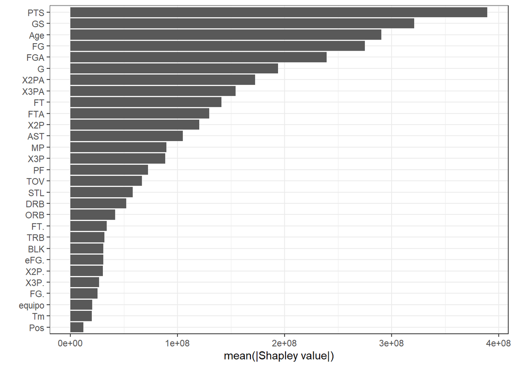

```r
theme_set(theme_bw())

# Aggregate Shapley values
shap_imp <- data.frame(
  Variable = names(shap),
  Importance = apply(shap, MARGIN = 2, FUN = function(x) sum(abs(x)))
)

# Plot Shap-based variable importance
ggplot(shap_imp, aes(reorder(Variable, Importance), Importance)) +
  geom_col() +
  coord_flip() +
  xlab("") +
  ylab("mean(|Shapley value|)")
```

#### Análisis local

Podemos ver la contribución de cada variable en la predicción del salario de un determinado jugador a partir del siguiente gráfico.

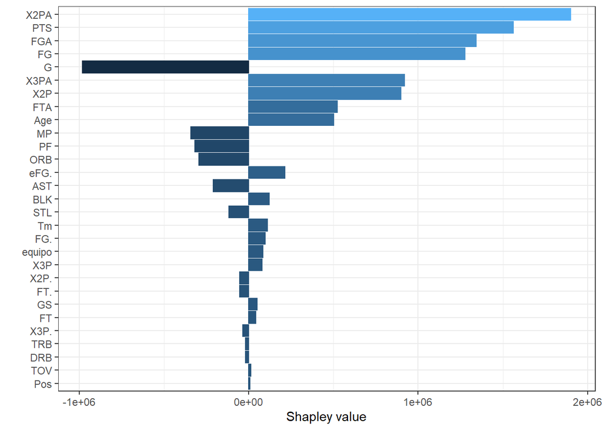

```r
# Plot individual explanations
expl <- explain(rfo, X = X,pred_wrapper = pfun, nsim = 10, newdata = X[1L,])
autoplot(expl, type = "contribution")
```

*PTS*

```r
X[1L, c("PTS", "X2PA", "G")]
```

|  | PTS | X2PA | G |
| --- | --- | --- | --- |
| 1 | 1126 | 574 | 75 |

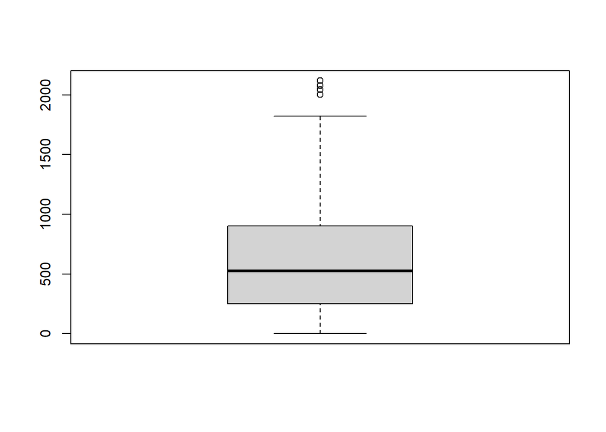

```r
boxplot(X$PTS)
```

PREDICCIÓN SALARIO JUGADOR Aaron Gordon (PSJ): 17.973.451

PREDICCIÓN SALARIO PROMEDIO (PSP): 9.620.020

SUMA SHAPLEY VALUES (SSV): 8.292.029

PSP + SSV ≈ PSJ

17.912.049 ≈ 17.973.451

(No son exactamente iguales, ya que el cálculo de los Shapley values es aproximado)

#### Análisis por variable

El siguiente tipo de gráfico nos permite explicar cómo influye el valor de una variable en la predicción.

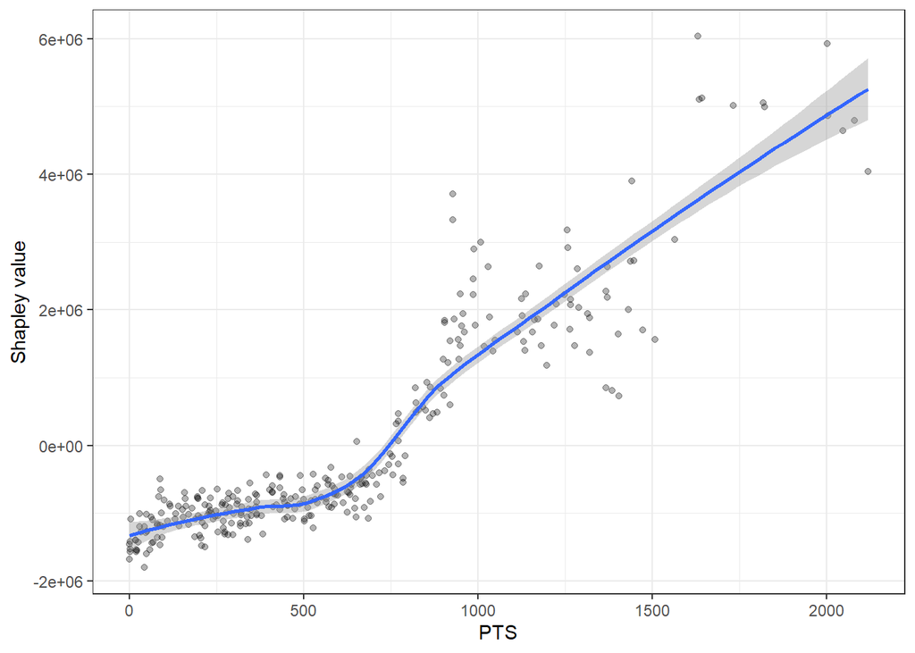

```r
var <- 'PTS'
shap_dep_x <- data.frame(x = X[[var]], shap = shap[[var]])
ggplot(shap_dep_x, aes(x, shap)) +
  geom_point(alpha = 0.3) +
  geom_smooth() +
  ylab("Shapley value") +
  xlab(var)
```

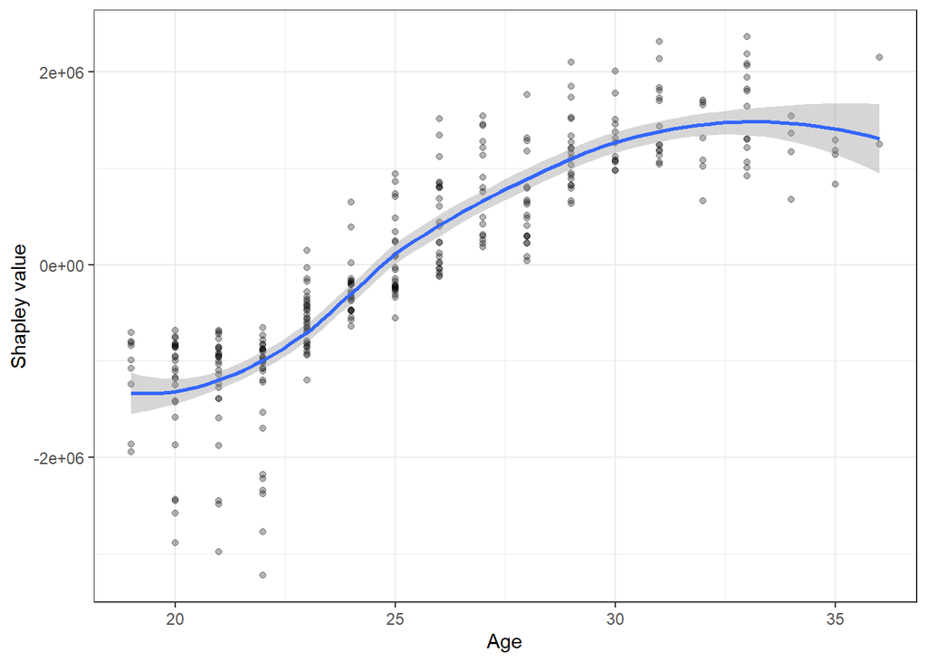

```r
var <- 'Age'
shap_dep_x <- data.frame(x = X[[var]], shap = shap[[var]])
ggplot(shap_dep_x, aes(x, shap)) +
  geom_point(alpha = 0.3) +
  geom_smooth() +
  ylab("Shapley value") +
  xlab(var)
```

# Referencias

- Bolaños, A. (2021). Kernel Shap, un paso adelante. (Serie ¡Explícate!). https://blogs.sas.com/content/sasla/2021/04/26/kernel-shap-un-paso-adelante-serie-explicate/
- Lingjærde, C., Jullum M. & Sellereite N. shapr: Explaining individual machine learning predictions with Shapley values. https://cran.r-project.org/web/packages/shapr/vignettes/understanding_shapr.html
- Lundberg, S. M. & Lee, S. (2017). A Unified Approach to Interpreting Model Predictions. https://doi.org/10.48550/arXiv.1705.07874
- Molnar, C. (2022). Interpretable Machine Learning: A guide for making black box
- Štrumbelj, E., & Kononenko, I. (2014). Explaining prediction models and individual predictions with feature contributions. Knowledge and information systems, 41(3), 647-665.
- Librería fastshap. https://bgreenwell.github.io/fastshap/articles/fastshap.html